# Cyclistic bike-share case study

Omotayo Ikudayisi

2024-06-19

# Cyclistic_Exercise_Full_Year_Analysis

This analysis is for case study 1 from the Google Data Analytics Certificate (Cyclistic). It’s originally based on the case study “‘Sophisticated, Clear, and Polished’: Divvy and Data Visualization” written by Kevin Hartman (found here: https://artscience.blog/home/divvy-dataviz-case-study). We will be using the Divvy dataset for the case study. The purpose of this script is to consolidate downloaded Divvy data into a single dataframe and then conduct simple analysis to help answer the key question: “In what ways do members and casual riders use Divvy bikes differently?”

```r
knitr::opts_chunk$set(echo = TRUE)
library(tidyverse)  #helps wrangle data
library(lubridate)  #helps wrangle date attributes
library(ggplot2)  #helps visualize data
library(dplyr)
#getwd() #displays your working directory
#setwd("C:/Users/Oikudayisi/Desktop/My textbook and Projects/R assignment/Client 2 Assignments/divvy dataset project") #sets your working directory to simplify calls to data ... make sure to use your OWN username instead of mine ;)
```

#===================== # STEP 1: COLLECT DATA #===================== # Upload Divvy datasets (csv files) here

```r
q1_2019 <- read_csv("Divvy_Trips_2019_Q1.csv")
q2_2019 <- read_csv("Divvy_Trips_2019_Q2.csv")
q3_2019 <- read_csv("Divvy_Trips_2019_Q3.csv")
q4_2019 <- read_csv("Divvy_Trips_2019_Q4.csv")
q1_2020 <- read_csv("Divvy_Trips_2020_Q1.csv")
```

#==================================================== # STEP 2: WRANGLE DATA AND COMBINE INTO A SINGLE FILE #==================================================== # Compare column names each of the files # While the names don’t have to be in the same order, they DO need to match perfectly before we can use a command to join them into one file

```r
colnames(q3_2019)
```

```
##  [1] "trip_id"           "start_time"        "end_time"
##  [4] "bikeid"            "tripduration"      "from_station_id"
##  [7] "from_station_name" "to_station_id"     "to_station_name"
## [10] "usertype"          "gender"            "birthyear"
```

```r
colnames(q4_2019)
```

```
##  [1] "trip_id"           "start_time"        "end_time"
##  [4] "bikeid"            "tripduration"      "from_station_id"
##  [7] "from_station_name" "to_station_id"     "to_station_name"
## [10] "usertype"          "gender"            "birthyear"
```

```r
colnames(q2_2019)
```

```
##  [1] "01 - Rental Details Rental ID"
##  [2] "01 - Rental Details Local Start Time"
##  [3] "01 - Rental Details Local End Time"
##  [4] "01 - Rental Details Bike ID"
##  [5] "01 - Rental Details Duration In Seconds Uncapped"
##  [6] "03 - Rental Start Station ID"
##  [7] "03 - Rental Start Station Name"
##  [8] "02 - Rental End Station ID"
##  [9] "02 - Rental End Station Name"
## [10] "User Type"
## [11] "Member Gender"
## [12] "05 - Member Details Member Birthday Year"
```

```r
colnames(q1_2020)
```

```
##  [1] "ride_id"            "rideable_type"      "started_at"
##  [4] "ended_at"           "start_station_name" "start_station_id"
##  [7] "end_station_name"   "end_station_id"     "start_lat"
## [10] "start_lng"          "end_lat"            "end_lng"
## [13] "member_casual"
```

## Rename columns to make them consisent with q1_2020 (as this will be the supposed going-forward table design for Divvy)

```r
#run once or error shows up
q4_2019 <- q4_2019 %>% rename(
                   ride_id = trip_id
                   ,rideable_type = bikeid
                   ,started_at = start_time
                   ,ended_at = end_time
                   ,start_station_name = from_station_name
                   ,start_station_id = from_station_id
                   ,end_station_name = to_station_name
                   ,end_station_id = to_station_id
                   ,member_casual = usertype)

q3_2019 <- q3_2019 %>%
                   rename(ride_id = trip_id
                   ,rideable_type = bikeid
                   ,started_at = start_time
                   ,ended_at = end_time
                   ,start_station_name = from_station_name
                   ,start_station_id = from_station_id
                   ,end_station_name = to_station_name
                   ,end_station_id = to_station_id
                   ,member_casual = usertype)

q2_2019 <- q2_2019 %>%
                   rename(ride_id = "01 - Rental Details Rental ID"
                   ,rideable_type = "01 - Rental Details Bike ID"
                   ,started_at = "01 - Rental Details Local Start Time"
                   ,ended_at = "01 - Rental Details Local End Time"
                   ,start_station_name = "03 - Rental Start Station Name"
                   ,start_station_id = "03 - Rental Start Station ID"
                   ,end_station_name = "02 - Rental End Station Name"
                   ,end_station_id = "02 - Rental End Station ID"
                   ,member_casual = "User Type")

q1_2019 <- q1_2019 %>%
                   rename(ride_id = trip_id
                   ,rideable_type = bikeid
                   ,started_at = start_time
                   ,ended_at = end_time
                   ,start_station_name = from_station_name
                   ,start_station_id = from_station_id
                   ,end_station_name = to_station_name
                   ,end_station_id = to_station_id
                   ,member_casual = usertype)
```

## Convert ride_id and rideable_type to character so that they can stack correctly

```r
q4_2019 <-  mutate(q4_2019, ride_id = as.character(ride_id)
                   ,rideable_type = as.character(rideable_type))
q3_2019 <-  mutate(q3_2019, ride_id = as.character(ride_id)
                   ,rideable_type = as.character(rideable_type))
q2_2019 <-  mutate(q2_2019, ride_id = as.character(ride_id)
                   ,rideable_type = as.character(rideable_type))

q1_2019 <-  mutate(q1_2019, ride_id = as.character(ride_id)
                   ,rideable_type = as.character(rideable_type))
```

## Stack individual quarter’s data frames into one big data frame

```r
all_trips <- bind_rows(q1_2019, q2_2019, q3_2019, q4_2019, q1_2020)
```

# Remove lat, long, birthyear, and gender fields as this data was dropped beginning in 2020

```r
all_trips <- all_trips %>%
  select(-c(start_lat, start_lng, end_lat, end_lng, birthyear, gender, "01 - Rental Details Duration In Seconds Uncapped", "05 - Member Details Member Birthday Year", "Member Gender", "tripduration"))
```

#====================================================== # STEP 3: CLEAN UP AND ADD DATA TO PREPARE FOR ANALYSIS #====================================================== # Inspect the new table that has been created

```r
colnames(all_trips)  #List of column names
```

```
## [1] "ride_id"            "started_at"         "ended_at"
## [4] "rideable_type"      "start_station_id"   "start_station_name"
## [7] "end_station_id"     "end_station_name"   "member_casual"
```

```r
nrow(all_trips)  #How many rows are in data frame?
```

```
## [1] 4244891
```

```r
dim(all_trips)  #Dimensions of the data frame?
```

```
## [1] 4244891       9
```

```r
head(all_trips)  #See the first 6 rows of data frame.  Also tail(qs_raw)
```

```
## # A tibble: 6 x 9
##   ride_id started_at          ended_at            rideable_type start_station_id
##   <chr>   <dttm>              <dttm>              <chr>                    <dbl>
## 1 217424~ 2019-01-01 00:04:37 2019-01-01 00:11:07 2167                       199
## 2 217424~ 2019-01-01 00:08:13 2019-01-01 00:15:34 4386                        44
## 3 217424~ 2019-01-01 00:13:23 2019-01-01 00:27:12 1524                        15
## 4 217424~ 2019-01-01 00:13:45 2019-01-01 00:43:28 252                        123
## 5 217424~ 2019-01-01 00:14:52 2019-01-01 00:20:56 1170                       173
## 6 217424~ 2019-01-01 00:15:33 2019-01-01 00:19:09 2437                        98
## # ... with 4 more variables: start_station_name <chr>, end_station_id <dbl>,
## #   end_station_name <chr>, member_casual <chr>
```

```r
str(all_trips)  #See list of columns and data types (numeric, character, etc)
```

```
## tibble [4,244,891 x 9] (S3: tbl_df/tbl/data.frame)
##  $ ride_id           : chr [1:4244891] "21742443" "21742444" "21742445" "21742446" ...
##  $ started_at        : POSIXct[1:4244891], format: "2019-01-01 00:04:37" "2019-01-01 00:08:13" ...
##  $ ended_at          : POSIXct[1:4244891], format: "2019-01-01 00:11:07" "2019-01-01 00:15:34" ...
##  $ rideable_type     : chr [1:4244891] "2167" "4386" "1524" "252" ...
##  $ start_station_id  : num [1:4244891] 199 44 15 123 173 98 98 211 150 268 ...
##  $ start_station_name: chr [1:4244891] "Wabash Ave & Grand Ave" "State St & Randolph St" "Racine Ave & 18th St" "California Ave & Milwaukee Ave" ...
##  $ end_station_id    : num [1:4244891] 84 624 644 176 35 49 49 142 148 141 ...
##  $ end_station_name  : chr [1:4244891] "Milwaukee Ave & Grand Ave" "Dearborn St & Van Buren St (*)" "Western Ave & Fillmore St (*)" "Clark St & Elm St" ...
##  $ member_casual     : chr [1:4244891] "Subscriber" "Subscriber" "Subscriber" "Subscriber" ...
```

```r
summary(all_trips)  #Statistical summary of data. Mainly for numerics
```

```
##    ride_id            started_at                     ended_at
##  Length:4244891     Min.   :2019-01-01 00:04:37   Min.   :2019-01-01 00:11:07
##  Class :character   1st Qu.:2019-06-05 11:55:20   1st Qu.:2019-06-05 12:16:37
##  Mode  :character   Median :2019-08-05 11:56:21   Median :2019-08-05 12:28:06
##                     Mean   :2019-08-09 22:35:19   Mean   :2019-08-09 22:59:17
##                     3rd Qu.:2019-10-06 08:15:10   3rd Qu.:2019-10-06 08:48:37
##                     Max.   :2020-03-31 23:51:34   Max.   :2020-05-19 20:10:34
##
##  rideable_type      start_station_id start_station_name end_station_id
##  Length:4244891     Min.   :  1.0    Length:4244891     Min.   :  1.0
##  Class :character   1st Qu.: 77.0    Class :character   1st Qu.: 77.0
##  Mode  :character   Median :174.0    Mode  :character   Median :174.0
##                     Mean   :202.5                       Mean   :203.3
##                     3rd Qu.:289.0                       3rd Qu.:291.0
##                     Max.   :675.0                       Max.   :675.0
##                                                         NA's   :1
##  end_station_name   member_casual
##  Length:4244891     Length:4244891
##  Class :character   Class :character
##  Mode  :character   Mode  :character
##
##
##
##
```

## There are a few problems we will need to fix:

## (1) In the “member_casual” column, there are two names for members (“member” and “Subscriber”) and two names for casual riders (“Customer” and “casual”). We will need to consolidate that from four to two labels.

## (2) The data can only be aggregated at the ride-level, which is too granular. We will want to add some additional columns of data – such as day, month, year – that provide additional opportunities to aggregate the data.

## (3) We will want to add a calculated field for length of ride since the 2020Q1 data did not have the “tripduration” column. We will add “ride_length” to the entire dataframe for consistency.

## (4) There are some rides where tripduration shows up as negative, including several hundred rides where Divvy took bikes out of circulation for Quality Control reasons. We will want to delete these rides.

## In the “member_casual” column, replace “Subscriber” with “member” and “Customer” with “casual”

## Before 2020, Divvy used different labels for these two types of riders … we will want to make our dataframe consistent with their current nomenclature

## N.B.: “Level” is a special property of a column that is retained even if a subset does not contain any values from a specific level

## Begin by seeing how many observations fall under each usertype

```r
table(all_trips$member_casual)
```

```
##
##     casual   Customer     member Subscriber
##      48480     880637     378407    2937367
```

## Reassign to the desired values (we will go with the current 2020 labels)

```r
all_trips <-  all_trips %>%
  mutate(member_casual = recode(member_casual
                                ,"Subscriber" = "member"
                                ,"Customer" = "casual"))
```

```r
# Check to make sure the proper number of observations were reassigned
table(all_trips$member_casual)
```

```
##
##  casual  member
##  929117 3315774
```

## Add columns that list the date, month, day, and year of each ride

## This will allow us to aggregate ride data for each month, day, or year … before completing these operations we could only aggregate at the ride level

## https://www.statmethods.net/input/dates.html more on date formats in R found at that link

```r
all_trips$date <- as.Date(all_trips$started_at) #The default format is yyyy-mm-dd
all_trips$month <- format(as.Date(all_trips$date), "%m")
all_trips$day <- format(as.Date(all_trips$date), "%d")
all_trips$year <- format(as.Date(all_trips$date), "%Y")
all_trips$day_of_week <- format(as.Date(all_trips$date), "%A")
```

## Add a “ride_length” calculation to all_trips (in seconds)

## https://stat.ethz.ch/R-manual/R-devel/library/base/html/difftime.html

```r
all_trips$ride_length <- difftime(all_trips$ended_at,all_trips$started_at)
```

## Inspect the structure of the columns to confirm made changes

```r
str(all_trips)
```

```
## tibble [4,244,891 x 15] (S3: tbl_df/tbl/data.frame)
##  $ ride_id           : chr [1:4244891] "21742443" "21742444" "21742445" "21742446" ...
##  $ started_at        : POSIXct[1:4244891], format: "2019-01-01 00:04:37" "2019-01-01 00:08:13" ...
##  $ ended_at          : POSIXct[1:4244891], format: "2019-01-01 00:11:07" "2019-01-01 00:15:34" ...
##  $ rideable_type     : chr [1:4244891] "2167" "4386" "1524" "252" ...
##  $ start_station_id  : num [1:4244891] 199 44 15 123 173 98 98 211 150 268 ...
##  $ start_station_name: chr [1:4244891] "Wabash Ave & Grand Ave" "State St & Randolph St" "Racine Ave & 18th St" "California Ave & Milwaukee Ave" ...
##  $ end_station_id    : num [1:4244891] 84 624 644 176 35 49 49 142 148 141 ...
##  $ end_station_name  : chr [1:4244891] "Milwaukee Ave & Grand Ave" "Dearborn St & Van Buren St (*)" "Western Ave & Fillmore St (*)" "Clark St & Elm St" ...
##  $ member_casual     : chr [1:4244891] "member" "member" "member" "member" ...
##  $ date              : Date[1:4244891], format: "2019-01-01" "2019-01-01" ...
##  $ month             : chr [1:4244891] "01" "01" "01" "01" ...
##  $ day               : chr [1:4244891] "01" "01" "01" "01" ...
##  $ year              : chr [1:4244891] "2019" "2019" "2019" "2019" ...
##  $ day_of_week       : chr [1:4244891] "Tuesday" "Tuesday" "Tuesday" "Tuesday" ...
##  $ ride_length       : 'difftime' num [1:4244891] 390 441 829 1783 ...
##   ..- attr(*, "units")= chr "secs"
```

```r
is.factor(all_trips$ride_length)
```

```
## [1] FALSE
```

```r
all_trips$ride_length <- as.numeric(as.character(all_trips$ride_length))
is.numeric(all_trips$ride_length)
```

```
## [1] TRUE
```

## The dataframe includes a few hundred entries when bikes were taken out of docks and checked for quality by Divvy or ride_length was negative

## We will create a new version of the dataframe (v2) since data is being removed

## https://www.datasciencemadesimple.com/delete-or-drop-rows-in-r-with-conditions-2/

```r
all_trips_v2 <- all_trips[!(all_trips$start_station_name == "HQ QR" | all_trips$ride_length<0),]
```

##===================================== ## STEP 4: CONDUCT DESCRIPTIVE ANALYSIS ##===================================== ## Descriptive analysis on ride_length (all figures in seconds)

```r
mean(all_trips_v2$ride_length) #straight average (total ride length / rides)
```

```
## [1] 1439.315
```

```r
median(all_trips_v2$ride_length) #midpoint number in the ascending array of ride lengths
```

```
## [1] 691
```

```r
max(all_trips_v2$ride_length) #longest ride
```

```
## [1] 10632022
```

```r
min(all_trips_v2$ride_length) #shortest ride
```

```
## [1] 1
```

## You can condense the four lines above to one line using summary() on the specific attribute

```r
summary(all_trips_v2$ride_length)
```

```
##     Min.  1st Qu.   Median     Mean  3rd Qu.     Max.
##        1      402      691     1439     1250 10632022
```

## Compare members and casual users

```r
aggregate(all_trips_v2$ride_length ~ all_trips_v2$member_casual, FUN = mean)
```

```
##   all_trips_v2$member_casual all_trips_v2$ride_length
## 1                     casual                3556.8495
## 2                     member                 848.3654
```

```r
aggregate(all_trips_v2$ride_length ~ all_trips_v2$member_casual, FUN = median)
```

```
##   all_trips_v2$member_casual all_trips_v2$ride_length
## 1                     casual                     1542
## 2                     member                      579
```

```r
aggregate(all_trips_v2$ride_length ~ all_trips_v2$member_casual, FUN = max)
```

```
##   all_trips_v2$member_casual all_trips_v2$ride_length
## 1                     casual                 10632022
## 2                     member                  9056634
```

```r
aggregate(all_trips_v2$ride_length ~ all_trips_v2$member_casual, FUN = min)
```

```
##   all_trips_v2$member_casual all_trips_v2$ride_length
## 1                     casual                        2
## 2                     member                        1
```

## See the average ride time by each day for members vs casual users

```r
aggregate(all_trips_v2$ride_length ~ all_trips_v2$member_casual + all_trips_v2$day_of_week, FUN = mean)
```

```
##    all_trips_v2$member_casual all_trips_v2$day_of_week all_trips_v2$ride_length
## 1                      casual                   Friday                3768.9980
## 2                      member                   Friday                 825.5616
## 3                      casual                   Monday                3359.6077
## 4                      member                   Monday                 845.8799
## 5                      casual                 Saturday                3339.9183
## 6                      member                 Saturday                 973.5914
## 7                      casual                   Sunday                3559.2956
## 8                      member                   Sunday                 927.2716
## 9                      casual                 Thursday                3803.1191
## 10                     member                 Thursday                 811.8656
## 11                     casual                  Tuesday                3562.1547
## 12                     member                  Tuesday                 829.8321
## 13                     casual                Wednesday                3702.9008
## 14                     member                Wednesday                 813.8020
```

## Notice that the days of the week are out of order. Let’s fix that.

```r
all_trips_v2$day_of_week <- ordered(all_trips_v2$day_of_week, levels=c("Sunday", "Monday", "Tuesday", "Wednesday", "Thursday", "Friday", "Saturday"))
```

## Now, let’s run the average ride time by each day for members vs casual users

```r
aggregate(all_trips_v2$ride_length ~ all_trips_v2$member_casual + all_trips_v2$day_of_week, FUN = mean)
```

```
##    all_trips_v2$member_casual all_trips_v2$day_of_week all_trips_v2$ride_length
## 1                      casual                   Sunday                3559.2956
## 2                      member                   Sunday                 927.2716
## 3                      casual                   Monday                3359.6077
## 4                      member                   Monday                 845.8799
## 5                      casual                  Tuesday                3562.1547
## 6                      member                  Tuesday                 829.8321
## 7                      casual                Wednesday                3702.9008
## 8                      member                Wednesday                 813.8020
## 9                      casual                 Thursday                3803.1191
## 10                     member                 Thursday                 811.8656
## 11                     casual                   Friday                3768.9980
## 12                     member                   Friday                 825.5616
## 13                     casual                 Saturday                3339.9183
## 14                     member                 Saturday                 973.5914
```

## analyze ridership data by type and weekday

```r
all_trips_v2 %>%
  mutate(weekday = wday(started_at, label = TRUE)) %>%  #creates weekday field using wday()
  group_by(member_casual, weekday) %>%  #groups by usertype and weekday
  summarise(number_of_rides = n()                           #calculates the number of rides and average duration
            ,average_duration = mean(ride_length)) %>%      # calculates the average duration
  arrange(member_casual, weekday)                               # sorts
```

```
## # A tibble: 14 x 4
## # Groups:   member_casual [2]
##    member_casual weekday number_of_rides average_duration
##    <chr>         <ord>             <int>            <dbl>
##  1 casual        Sun              185059            3559.
##  2 casual        Mon              105188            3360.
##  3 casual        Tue               93238            3562.
##  4 casual        Wed               94946            3703.
##  5 casual        Thu              105599            3803.
##  6 casual        Fri              125779            3769.
##  7 casual        Sat              215536            3340.
##  8 member        Sun              292198             927.
##  9 member        Mon              520703             846.
## 10 member        Tue              566722             830.
## 11 member        Wed              558254             814.
## 12 member        Thu              548160             812.
## 13 member        Fri              512462             826.
## 14 member        Sat              317267             974.
```

## Let’s visualize the number of rides by rider type

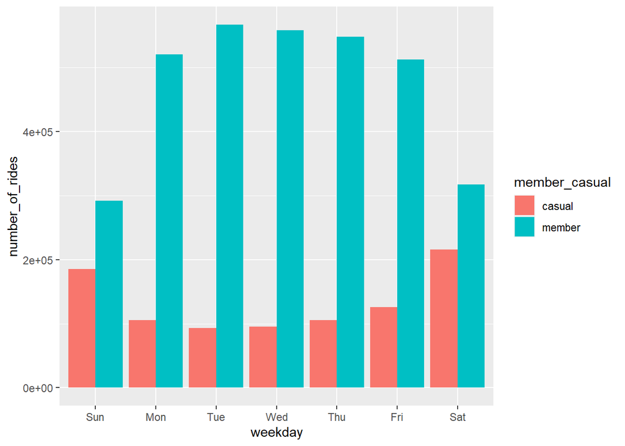

```r
all_trips_v2 %>%
  mutate(weekday = wday(started_at, label = TRUE)) %>%
  group_by(member_casual, weekday) %>%
  summarise(number_of_rides = n()
            ,average_duration = mean(ride_length)) %>%
  arrange(member_casual, weekday)  %>%
  ggplot(aes(x = weekday, y = number_of_rides, fill = member_casual)) +
  geom_col(position = "dodge")
```

## Let’s create a visualization for average duration

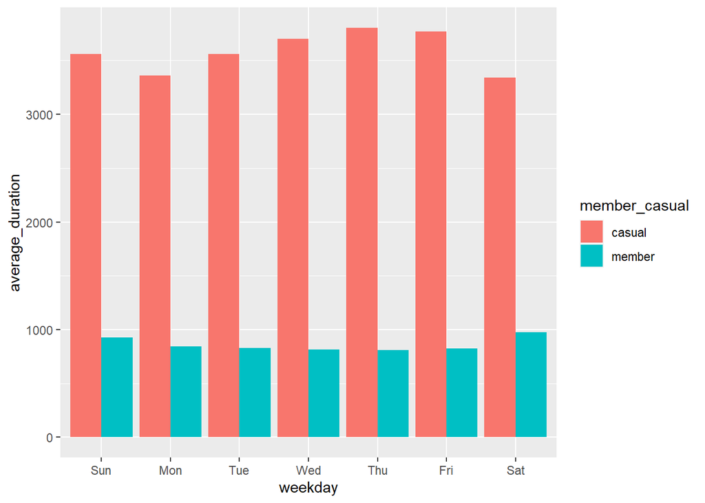

```r
all_trips_v2 %>%
  mutate(weekday = wday(started_at, label = TRUE)) %>%
  group_by(member_casual, weekday) %>%
  summarise(number_of_rides = n()
            ,average_duration = mean(ride_length)) %>%
  arrange(member_casual, weekday)  %>%
  ggplot(aes(x = weekday, y = average_duration, fill = member_casual)) +
  geom_col(position = "dodge")
```

##================================================= ## STEP 5: EXPORT SUMMARY FILE FOR FURTHER ANALYSIS ##================================================= ## Create a csv file that we will visualize in Excel, Tableau, or my presentation software ## N.B.: This file location is for a Mac. If you are working on a PC, change the file location accordingly (most likely “C:_USERNAME...”) to export the data. You can read more here: https://datatofish.com/export-dataframe-to-csv-in-r/

```r
counts <- aggregate(all_trips_v2$ride_length ~ all_trips_v2$member_casual + all_trips_v2$day_of_week, FUN = mean)
write.csv(counts, file = '/avg_ride_length.csv')
```

#You’re done! Congratulations!